# ErikVan_A5

Erik Van

10/26/2021

# CEE 218X Assignment 5

# The following is a Bay Area map of PM2.5 Concentrations.

[interactive chart not shown]

## Comments on PM2.5 Map

### As seen in the above map, the highest PM2.5 concentration in the Bay Area is the Oakland area. There is also a pocket of very high PM2.5 concentration in Napa. There is a general trend that there is higher concentrations of PM2.5 in the center of the bay area (more in-land) as opposed to the edges of the bay area (i.e San Jose and Santa Rosa).

# The following is a Bay Area map of Asthma Concentrations.

[interactive chart not shown]

## Comments on Asthma Map

### As seen in the above map, the highest asthma concentration in the Bay Area is in Vallejo, between Alameda/San Leandro, and Antioch. There is a general trend that asthma in the bay area is relatively low with pockets of high concentration. These pockets tend to be in the center of the bay area (more in-land) as opposed to the edges of the bay area (i.e San Jose and Santa Rosa).

# The following is scatter plot with PM2.5 on the x-axis and Asthma on the y-axis in the Bay Area, with a best-fit line.

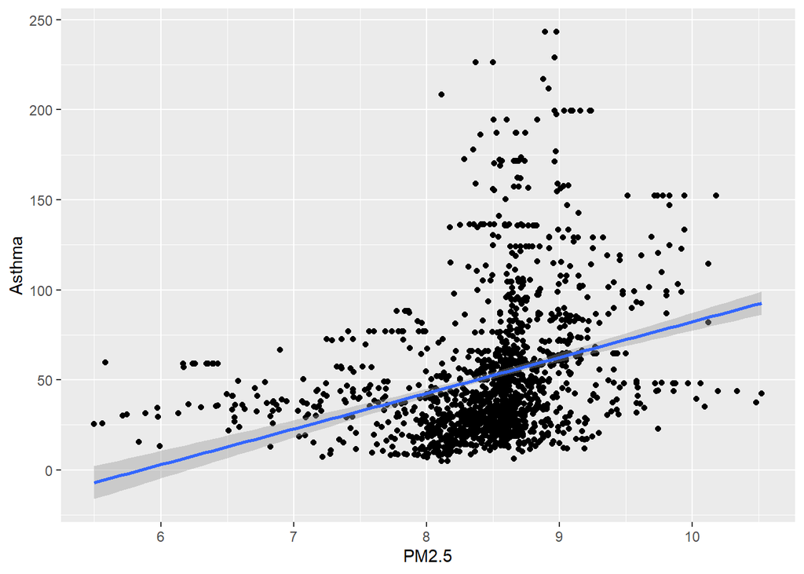

## Comment on the apparent “fitness” of the best-fit line at this stage

### The best fit line is skewed towards the bottom because of the high concentration of data points on the bottom of the graph. Because of that, the best fit line is underestimating many of the data points above it and doesn’t account for most of the asthma points above 100. Overall, this line isn’t a good fit for this data.

# Perform a linear regression analysis

```
##
## Call:
## lm(formula = Asthma ~ PM2.5, data = ces4_bay_total)
##
## Residuals:
##    Min     1Q Median     3Q    Max
## -54.47 -25.89  -9.61  12.94 182.95
##
## Coefficients:
##             Estimate Std. Error t value Pr(>|t|)
## (Intercept) -116.278     13.040  -8.917   <2e-16 ***
## PM2.5         19.862      1.534  12.950   <2e-16 ***
## ---
## Signif. codes:  0 '***' 0.001 '**' 0.01 '*' 0.05 '.' 0.1 ' ' 1
##
## Residual standard error: 37.49 on 1578 degrees of freedom
##   (1 observation deleted due to missingness)
## Multiple R-squared:  0.09606,    Adjusted R-squared:  0.09549
## F-statistic: 167.7 on 1 and 1578 DF,  p-value: < 2.2e-16
```

## Comment linear regression results

### “R-squared” is a measure of the shared variance between the x and y values. Variation in PM2.5 explains 9.606% of the variation in asthma.

### Looking at the residuals from the lm() function, the line of best fit is skewed towards underestimation. With a median of -9.61, a min of -54.47, and a max of 182.95, there is a skew towards underestimation. The min and max values don’t have a symmetrical distribution and the median was not centered around zero so a linear regression may not be the best fit for this data.

# The following is a plot of residuals densities

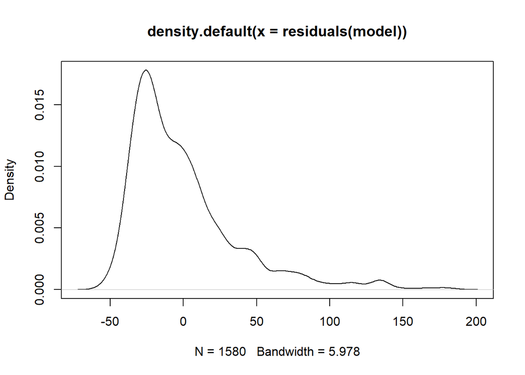

# The following is scatter plot with PM2.5 on the x-axis and log(Asthma) on the y-axis in the Bay Area, with a best-fit line.

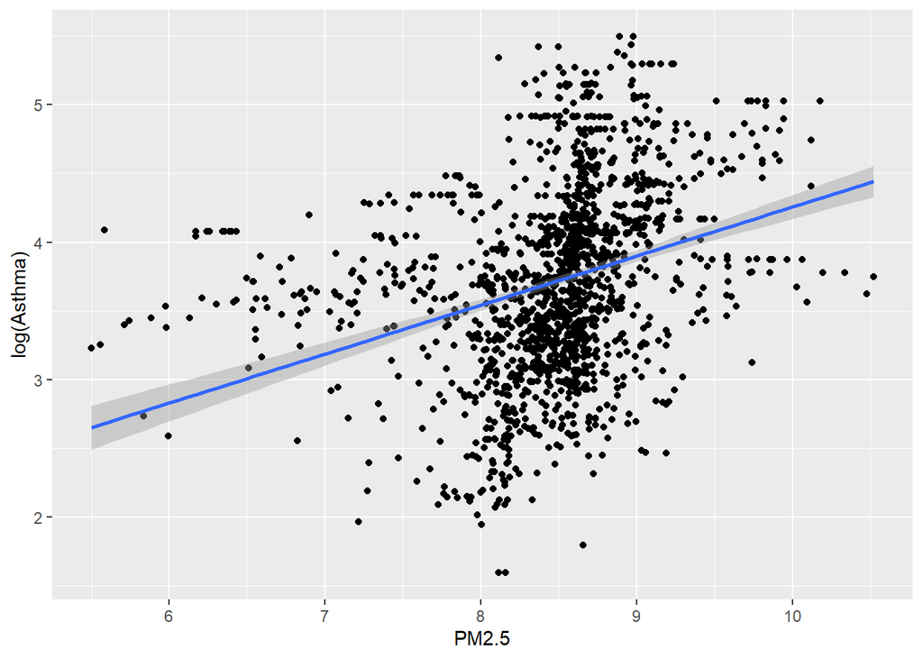

## Comment on the apparent “fitness” of the best-fit line at this stage

### The best fit line is a lot more centered than in the linear regression. The best fit line seems to capture more of the data and doesn’t lean towards over or under estimation. This trend line seems to fit the data more. There are some extremes that the best fit line doesn’t capture but a log regression does a better job than the linear regression.

# Perform a regression analysis

```
##
## Call:
## lm(formula = log(Asthma) ~ PM2.5, data = ces4_bay_total)
##
## Residuals:
##      Min       1Q   Median       3Q      Max
## -2.00402 -0.46479  0.03313  0.42298  1.75525
##
## Coefficients:
##             Estimate Std. Error t value Pr(>|t|)
## (Intercept)  0.69234    0.22840   3.031  0.00248 **
## PM2.5        0.35633    0.02686  13.264  < 2e-16 ***
## ---
## Signif. codes:  0 '***' 0.001 '**' 0.01 '*' 0.05 '.' 0.1 ' ' 1
##
## Residual standard error: 0.6566 on 1578 degrees of freedom
##   (1 observation deleted due to missingness)
## Multiple R-squared:  0.1003, Adjusted R-squared:  0.09974
## F-statistic: 175.9 on 1 and 1578 DF,  p-value: < 2.2e-16
```

## Comment regression results

### “R-squared” is a measure of the shared variance between the x and y values. Variation in PM2.5 explains 10.03% of the variation in asthma.

### Looking at the residuals from the lm() function, the line of best fit for this plot is a better fit than the linear plot- there is less skew towards over over or under estimation. With a median of .03313, a min of -2.004, and a max of 1.755, the min and max values have a better symmetrical distribution and the median is centered around zero so this regression is a better best fit for this data.

# The following is a plot of residuals densities

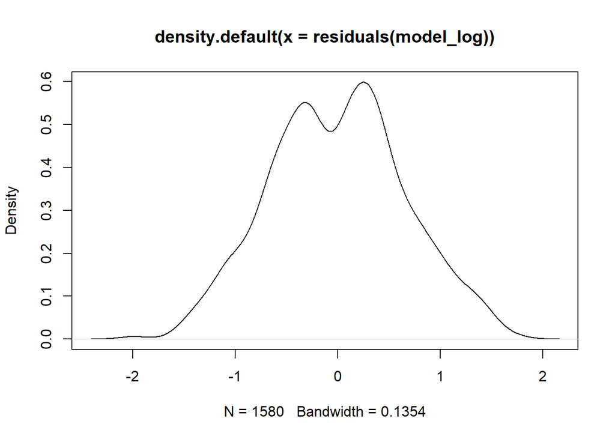